# Data Science with R, Part 2: Beyond Basics

May 21, 2018

This post is the second part of Data Science with R series.

Previous post in Data Science with R:

1. [Data Science with R, Part 1: Introduction to R](https://azmirfakkri.github.io/2018/05/16/Data_Science_with_R_Pt_1.html)

# Conditionals and Control Flow

## Relational Operators

Relational operators allow us to compare values in R. When I said values, it includes logicals, numerics and characters.

- **Equality**
  - `==` - equal to
  - `!=` - not equal to
- **Less and greater than**
  - `<` - less than
  - `>` - greater than
  - `<=` - less than or equal to
  - `>=` - greater than or equal to

Important - single `=` is the same as `<-` in R, use for assigning a value to a variable.

Now let’s see how we can use these operators.

```r
# Assign value to a variable
a <- 1
b <- 10

# a is equal to b
a == b
```

```
## [1] FALSE
```

```r
# a is not equal to b
a != b
```

```
## [1] TRUE
```

Note that the result of these comparisons will be Boolean, `true` or `false`.

Let’s see another example using vectors of numerics.

```r
# Create vectors
d <- c(1, 7, 3, 9, 5)
e <- c(6, 2, 8, 4, 10)

# d is greater than e
d > e
```

```
## [1] FALSE  TRUE FALSE  TRUE FALSE
```

```r
# d is less than e
d < e
```

```
## [1]  TRUE FALSE  TRUE FALSE  TRUE
```

Important - Under the hood in R, `TRUE` is equal to 1, `FALSE` is equal to 0. This characteristic is useful in this situation where we want to count something in R.

```r
# Create a character vector
f <- c("a", "a", "a", "a", "a", "a", "a", "a", "b", "b", "b", "b")


# Count how many "a" in vector f
sum(f == "a")
```

```
## [1] 8
```

```r
# Let's see the result of f == "a"
f == "a"
```

```
##  [1]  TRUE  TRUE  TRUE  TRUE  TRUE  TRUE  TRUE  TRUE FALSE FALSE FALSE
## [12] FALSE
```

`sum()` will interpret `TRUE` as 1 and add these and return us with a sum value. We can see that there 8 true’s in the result.

Now, let’s use this relational operators in a dataset. This example will use ‘quine’ dataset in MASS package. You can use a question mark to read the description of the dataset, like this, `?quine`

```r
# Load MASS package
library(MASS)

# Create a subset: all aboriginal students
abo <- subset(quine, Eth == "A")

# View abo
abo
```

```
##    Eth Sex Age Lrn Days
## 1    A   M  F0  SL    2
## 2    A   M  F0  SL   11
## 3    A   M  F0  SL   14
## 4    A   M  F0  AL    5
## 5    A   M  F0  AL    5
## 6    A   M  F0  AL   13
## 7    A   M  F0  AL   20
## 8    A   M  F0  AL   22
## 9    A   M  F1  SL    6
## 10   A   M  F1  SL    6
## 11   A   M  F1  SL   15
## 12   A   M  F1  AL    7
## 13   A   M  F1  AL   14
## 14   A   M  F2  SL    6
```

[output cut: 55 more lines]

Our `abo` now contains only Aboriginal students.

## Logical Operators

Logical operators is used to do Boolean operations.

- **AND** - `&`
  - `TRUE` & `TRUE` returns `TRUE`
  - `TRUE` & `FALSE` returns `FALSE`
  - `FALSE` & `FALSE` returns `FALSE`
- **OR** - `|`
  - `TRUE` | `TRUE` returns `TRUE`
  - `TRUE` | `FALSE` returns `TRUE`
  - `FALSE` | `FALSE` returns `FALSE`
- **NOT** - `!` (negates output)
  - `!TRUE` returns `FALSE`
  - `!FALSE` returns `TRUE`

Let’s see these operators in action.

```r
# Create a subset of quine dataset: Aboriginal, Male students
abom <- subset(quine, Eth == "A" & Sex == "M")

# View abom
abom
```

```
##    Eth Sex Age Lrn Days
## 1    A   M  F0  SL    2
## 2    A   M  F0  SL   11
## 3    A   M  F0  SL   14
## 4    A   M  F0  AL    5
## 5    A   M  F0  AL    5
## 6    A   M  F0  AL   13
## 7    A   M  F0  AL   20
## 8    A   M  F0  AL   22
## 9    A   M  F1  SL    6
## 10   A   M  F1  SL    6
## 11   A   M  F1  SL   15
## 12   A   M  F1  AL    7
## 13   A   M  F1  AL   14
## 14   A   M  F2  SL    6
```

[output cut: 17 more lines]

## `if`, `else if` and `else` Statements

Let’s look at the structure of writing a combination of these three statements.

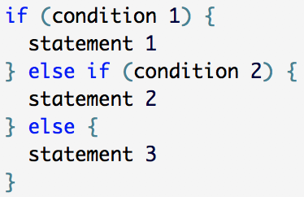

A few things you need to note:

- Conditions must be in parentheses `()`
- Statements are enclosed in curly brackets `{}`
- `else if` comes between the `if` and `else` statements

Before we create an example, let’s understand how these statements are executed.

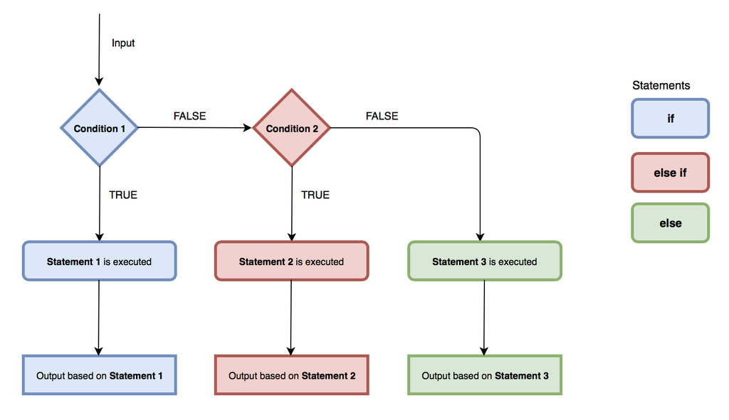

Let’s start with our `if` statement. If the condition for our `if` is satisfied, the statement for `if` will be executed and the output produced will be based on the statement for `if`.

If the condition for `if` is not satisfied, R will evaluate the next condition, in this case, I have included `else if`, so R will evaluate the condition in `else if` statement. If the condition for our `else if` is satisfied, the statement for `else if` will be executed and the output produced will be based on the statement for `else if`.

If the condition for `else if` is not satisfied, R will evaluate our final statement, `else` statement. The statement for `else` will be executed and the output produced will be based on the statement for `else`.

Important:

- An `if` statement alone can run on its own without having to have `else if` or `else` statements attached to it, but this does not hold true for `else if` or `else`
- It should be noted that `else if` is almost like an optional statement, which means that if there is no `else if` statement but `else` statement is present, R will move to `else` statement
- You can have a few `else if` statements
- Once a condition is satisfied, R will ignore the rest of the conditions that come after that

Let’s see how these statements work based on this example.

```r
g <- 10

# Condition of if statement is satisfied
if (g < 13) {
  print("g is less than 13")
} else if (g == 13) {
  print("g is 13")
} else {
  print("g is greater than 13")
}
```

```
## [1] "g is less than 13"
```

Notice that, R has ignored the `else if` and `else` statements since the `if` condition is satisfied.

```r
g <- 13

# Condition of else if statement is satisfied
if (g < 13) {
  print("g is less than 13")
} else if (g == 13) {
  print("g is 13")
} else {
  print("g is greater than 13")
}
```

```
## [1] "g is 13"
```

```r
g <- 14

# Two else if statements, condition of second else if statement is satisfied
if (g < 13) {
  print("g is less than 13")
} else if (g == 13) {
  print("g is 13")
} else if (g == 14) {
  print("Oh it's 14!")
} else {
  print("g is greater than 13")
}
```

```
## [1] "Oh it's 14!"
```

```r
g <- 15

# No conditions are satisfied, so else statement is executed
if (g < 13) {
  print("g is less than 13")
} else if (g == 13) {
  print("g is 13")
} else {
  print("g is greater than 13")
}
```

```
## [1] "g is greater than 13"
```

# Loops

In data analysis, often you will find yourself doing a repeated action, for example, extracting certain information and dump the result into a new column. This repetitive task can be automated by using loops in R. We will cover two loops in this article: `while` and `for`.

## While Loop

Similar to the `if` statement, `while` loop has a condition, statement to be executed and on top of that, the loop needs to initialised for it to run. Let’s see the structure of a `while` loop.

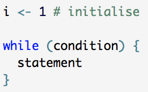

Since we have learnt the conditional statements, let’s throw an `if` statement in the while loop for the craic. This time, I will introduce you to the `break` statement. It will stop the execution of the `while` loop when the condition is met.

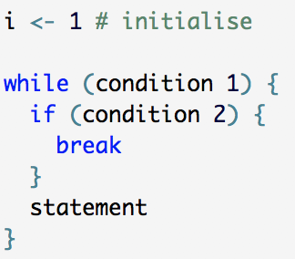

Before, we create an example, let’s see how a `while` loop is executed.

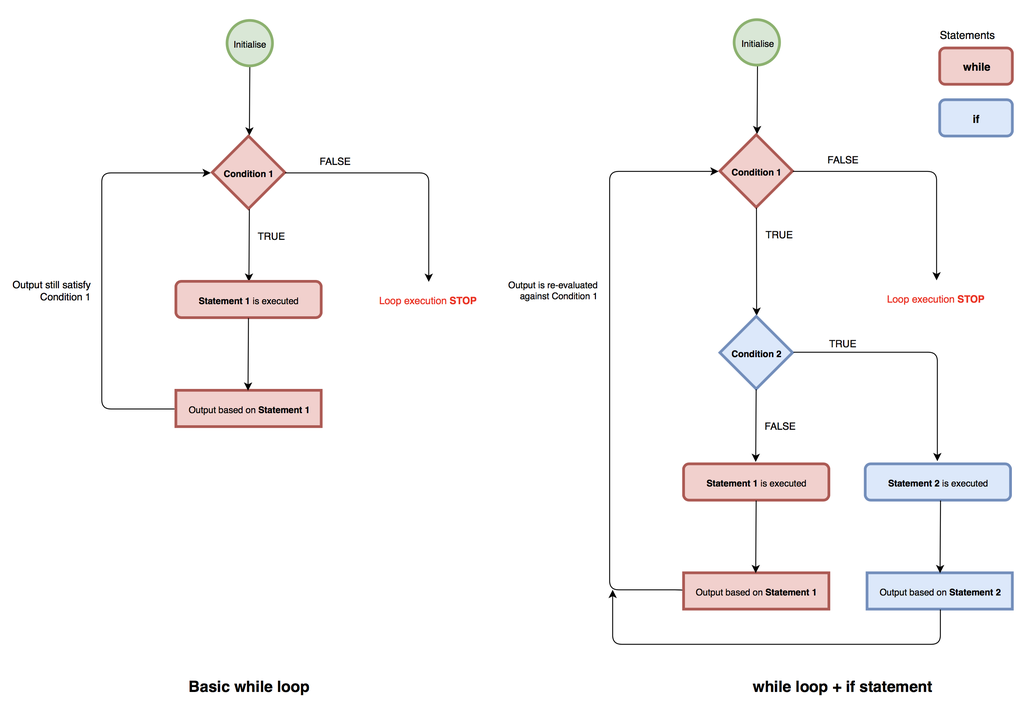

From the flow diagram, we can see that a `while` loop will keep running as long as the condition is satisfied. The output will be re-evaluated against the condition after each cycle or iteration. Now, let’s play.

```r
# Initialise while loop
dogs <- 1

# while loop (basic)
while (dogs < 8) {
  print(paste("I have ", dogs, " doggos!")) # statement 1
  dogs = dogs + 1 # increment
}
```

```
## [1] "I have  1  doggos!"
## [1] "I have  2  doggos!"
## [1] "I have  3  doggos!"
## [1] "I have  4  doggos!"
## [1] "I have  5  doggos!"
## [1] "I have  6  doggos!"
## [1] "I have  7  doggos!"
```

From the output, we can see that 8 is not included as we use the `<` operator instead of `<=`. We can also see that the first output, is grammatically wrong in the doggo world. Let’s fix this with an `if` statement.

```r
# Initialise while loop
dogs <- 1

# while loop with an if and else statements
while (dogs < 8) {
  if (dogs == 1) {
    print(paste("I have ", dogs, " doggo!")) # statement 2
  } else
  print(paste("I have ", dogs, " doggos!")) # statement 1
  dogs = dogs + 1 # increment
}
```

```
## [1] "I have  1  doggo!"
## [1] "I have  2  doggos!"
## [1] "I have  3  doggos!"
## [1] "I have  4  doggos!"
## [1] "I have  5  doggos!"
## [1] "I have  6  doggos!"
## [1] "I have  7  doggos!"
```

In our second `while` loop, we have put an `if` and also an `else`. If we don’t put an `else`, “I have 1 doggos!” will still be printed as an output and we don’t want that.

Let’s throw in the `break` statement in our `while` loop.

```r
# Initialise while loop
dogs <- 1

# while loop with a break statement + if, else if, else statements
while (dogs < 8) {
  if (dogs == 1) {
    print(paste("I have ", dogs, " doggo!")) # statement 2
  } else if (dogs == 5) {                    # break statement
    break
  } else
  print(paste("I have ", dogs, " doggos!")) # statement 1
  dogs = dogs + 1 # increment
}
```

```
## [1] "I have  1  doggo!"
## [1] "I have  2  doggos!"
## [1] "I have  3  doggos!"
## [1] "I have  4  doggos!"
```

## For Loop

Our next loop is the famous `for` loop. The structure of this loop is slightly different from `while` loop.

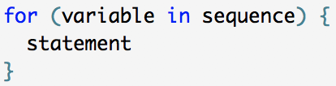

Let’s see the flow diagram of a `for` loop.

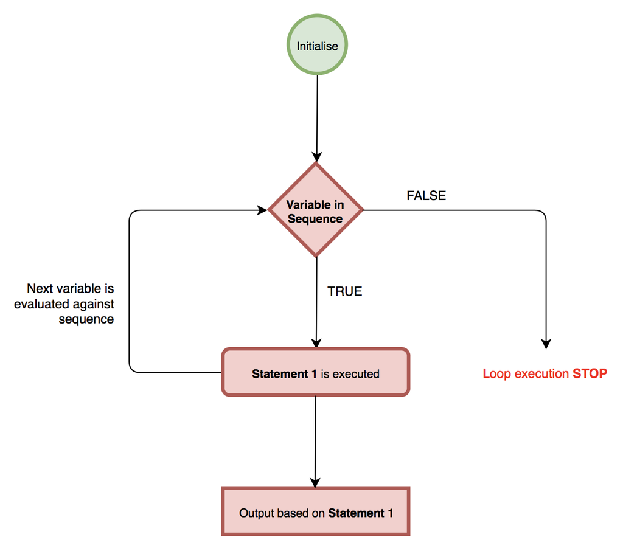

The difference in the `for` loop:

- Instead of condition, variables in the sequence are evaluated, which means, `for` loop will execute the statement if the variable **is in the sequence**, if it is not in the sequence, the `for` loop will not execute the statement
- The output is not evaluated to keep the `for` loop running

Let’s create a `for` loop.

```r
# Create vector
doggies <- c("Jodi", "Loki", "Ru", "Pip", "Bear")

# Create a simple for loop
for (dogs in doggies) {                   # variable in sequence
  print(paste("My dog's name is", dogs))  # statement 1
}
```

```
## [1] "My dog's name is Jodi"
## [1] "My dog's name is Loki"
## [1] "My dog's name is Ru"
## [1] "My dog's name is Pip"
## [1] "My dog's name is Bear"
```

Let’s throw in a `break` statement into our `for` loop.

```r
# Create a loop with a break statement
for (dogs in doggies) {                   # variable in sequence
  if (nchar(dogs) == 2) {                 # condition for if statement
    break                                 # break statement
  }
  print(paste("My dog's name is", dogs))  # statement 1
}
```

```
## [1] "My dog's name is Jodi"
## [1] "My dog's name is Loki"
```

In this loop, we have specified that the loop should stop when it encounters a dog’s name of two characters `nchar(dogs) == 2`. So, only Jodi and Loki are printed out. They are the best dogs in the world!

But what if we still want the `for` loop to go through Pip and Bear? We can do that by using a `next` statement instead of `break`.

```r
# Create a loop with a next statement
for (dogs in doggies) {                   # variable in sequence
  if (nchar(dogs) == 2) {                 # condition for if statement
    next                                  # next statement
  }
  print(paste("My dog's name is", dogs))  # statement 1
}
```

```
## [1] "My dog's name is Jodi"
## [1] "My dog's name is Loki"
## [1] "My dog's name is Pip"
## [1] "My dog's name is Bear"
```

What if we want to print “Jodi is dog number 1 in the list”? How do we iterate this process using the `for` loop?

```r
# Create a generalised for loop
for (dogs in 1:length(doggies)) {                                    # variable in sequence
  print(paste(doggies[dogs], "is dog number", dogs, "in the list"))  # statement 1
}
```

```
## [1] "Jodi is dog number 1 in the list"
## [1] "Loki is dog number 2 in the list"
## [1] "Ru is dog number 3 in the list"
## [1] "Pip is dog number 4 in the list"
## [1] "Bear is dog number 5 in the list"
```

Let’s see the result of `1:length(doggies)`.

```r
# View 1:length(doggies)
1:length(doggies)
```

```
## [1] 1 2 3 4 5
```

So, `dogs in 1:length(doggies)`, will take these values for every iteration, first iteration dogs is 1, second iteration dog is 2 and so on.

# lapply, sapply, vapply

## lapply

`lapply()` is a function in the apply family. It applies a function over a list or a vector. It is important to note that `lapply()` will always return a list. l for list, easy to remember. `lapply()` takes two arguments: `lapply(list/vector, function to be applied)`.

Let’s use our doggies example. Say we want to print the number of characters for the dog’s names, we can do that using a `for` loop, but it is easier to do this using `lapply()`. It will apply the `nchar()` function to every element in the our doggies vector.

```r
# Print number of characters using for loop
for (dogs in doggies) {
  print(nchar(dogs))
}
```

```
## [1] 4
## [1] 4
## [1] 2
## [1] 3
## [1] 4
```

```r
# Print number of characters using lapply
lapply(doggies, nchar)
```

```
## [[1]]
## [1] 4
##
## [[2]]
## [1] 4
##
## [[3]]
## [1] 2
##
## [[4]]
## [1] 3
##
## [[5]]
## [1] 4
```

If we don’t want the result in a form of list, we can wrap it with `unlist()` function. The result will be a vector instead of a list.

```r
unlist(lapply(doggies, nchar))
```

```
## [1] 4 4 2 3 4
```

## sapply

`sapply()` is a function that will simplify the result. This function has two default arguments `simplify = TRUE, USE.NAMES = TRUE`.

```r
sapply(doggies, nchar)
```

```
## Jodi Loki   Ru  Pip Bear
##    4    4    2    3    4
```

From the result, we can see that `sapply()` returns an array instead of a list. If we don’t want the names, we can suppress this behaviour like this.

```r
sapply(doggies, nchar, USE.NAMES = FALSE)
```

```
## [1] 4 4 2 3 4
```

Important: If `sapply()` cannot simplify the result, it will return a list, just like `lapply()`.

## vapply

As mentioned earlier, `sapply()` can’t handle and simplify everything. So, `vapply()` is a safer option, but with that, comes extra arguments that you have to specify. In `vapply()`, these are the arguments that you need to specify `vapply(X, FUN, FUN.VALUE, ..., USE.NAMES = TRUE)`. `X`, `FUN` and `FUN.VALUE` are compulsory.

```r
vapply(doggies, nchar, numeric(1))
```

```
## Jodi Loki   Ru  Pip Bear
##    4    4    2    3    4
```

`FUN.VALUE` is the template for return value. `numeric(1)` means that you want numeric values of length 1 to be returned.

## Recap

Let’s recap. We have three functions in the apply family:

1. `lapply()` - `lapply(list/vector, function to be applied)`
   - Result is returned as list
2. `sapply()` - `sapply(list/vector, function to be applied, USE.NAMES = TRUE)`
   - Result is simplified into array, but can’t simplify everything
   - As default, it will return a named array, can suppress this by specifying `USE.NAMES = FALSE`
3. `vapply()` - `vapply(list/vector, function to be applied, template for result, USE.NAMES = TRUE)`
   - Need to specify template for result
   - A safer option in simplifying result in comparison to `sapply()`

Previous post

Data Science with R, Part 1: Introduction to Basics

Next post

Data Science with Python, Part 1: Introduction to Basics